# Final Project

#### **Step 7.b: Hierarchical Clustering**

```r
# Load necessary libraries
library(cluster)
library(factoextra)

# Compute Distance Matrix
distance_matrix <- dist(scaled_clustering_data, method = "euclidean")

# Perform Hierarchical Clustering
hierarchical_result <- hclust(distance_matrix, method = "ward.D2")

# Print summary of hierarchical clustering
summary(hierarchical_result)
```

```
##             Length Class  Mode
## merge       1876   -none- numeric
## height       938   -none- numeric
## order        939   -none- numeric
## labels       939   -none- character
## method         1   -none- character
## call           3   -none- call
## dist.method    1   -none- character
```

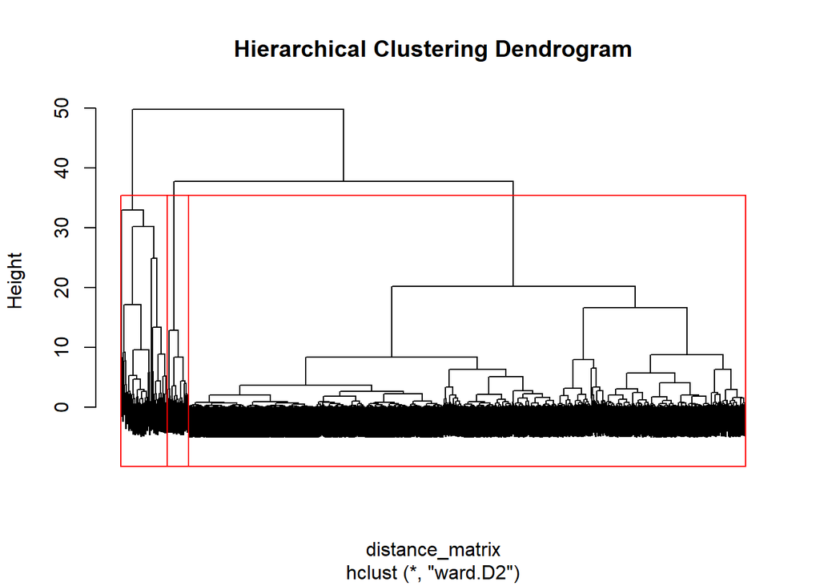

```r
# Plot the dendrogram for hierarchical clustering
plot(hierarchical_result, labels = FALSE, main = "Hierarchical Clustering Dendrogram")
rect.hclust(hierarchical_result, k = 3, border = "red")  # Highlight 3 clusters
```

The dendrogram represents a hierarchical grouping of YouTube channels based on similarities in scaled features. The red rectangles outline three clusters identified from the tree: Cluster 1: Low-performing channels. Cluster 2: Medium-performing channels. Cluster 3: High-performing channels. Key Details from Clustering Object:

Merge Matrix: Indicates the pairs of clusters merged at each step. Height: Reflects the distance at which merges occurred, with higher merges representing less similarity. Order: Specifies the order of observations in the plot. Labels: Contains channel identifiers for detailed interpretation. Method: “Ward.D2” minimizes the total within-cluster variance.

The compaison :

Comparison Between K-Means and Hierarchical Clustering Similarities: Both methods segmented channels into low, medium, and high performers. Identified meaningful patterns within the dataset. Differences: Hierarchical clustering provides a nested relationship between clusters and is ideal for smaller datasets or exploratory analysis. K-Means is more computationally efficient for large datasets but does not reveal hierarchical relationships. Final Comments: Both methods are complementary. Hierarchical clustering provides more interpretability, while K-Means offers scalability. Depending on the use case, one may choose either based on dataset size and desired output.

### **Step 8: Classification**

#### **Step 8.a: Decision Tree Classification**

```r
# Load necessary libraries
library(rpart)
library(rpart.plot)

# Prepare the data for classification
classification_data <- youtube_data %>%
  mutate(is_high_performing = ifelse(subscribers > median(subscribers, na.rm = TRUE), 1, 0)) %>%
  select(is_high_performing, video.views, uploads, highest_yearly_earnings, video_views_for_the_last_30_days) %>%
  na.omit()



# Split the data into training and testing sets
set.seed(123)
train_index <- sample(1:nrow(classification_data), 0.7 * nrow(classification_data))
train_data <- classification_data[train_index, ]
test_data <- classification_data[-train_index, ]

# Train a Decision Tree classifier
decision_tree <- rpart(is_high_performing ~ ., data = train_data, method = "class")

# Print summary of the decision tree
summary(decision_tree)
```

```
## Call:
## rpart(formula = is_high_performing ~ ., data = train_data, method = "class")
##   n= 657
##
##           CP nsplit rel error    xerror       xstd
## 1 0.43251534      0 1.0000000 1.1042945 0.03913174
## 2 0.01380368      1 0.5674847 0.5981595 0.03592014
## 3 0.01150307      3 0.5398773 0.6134969 0.03618035
## 4 0.01000000      7 0.4938650 0.6165644 0.03623099
##
## Variable importance
##                      video.views          highest_yearly_earnings
##                               52                               20
## video_views_for_the_last_30_days                          uploads
##                               19                                9
##
## Node number 1: 657 observations,    complexity param=0.4325153
##   predicted class=1  expected loss=0.4961948  P(node) =1
##     class counts:   326   331
##    probabilities: 0.496 0.504
##   left son=2 (397 obs) right son=3 (260 obs)
##   Primary splits:
##       video.views                      < 9788410000 to the left,  improve=66.012320, (0 missing)
##       video_views_for_the_last_30_days < 121500500  to the left,  improve=21.735270, (0 missing)
##       highest_yearly_earnings          < 5850000    to the left,  improve=21.554030, (0 missing)
##       uploads                          < 130801     to the right, improve= 3.814495, (0 missing)
##   Surrogate splits:
##       highest_yearly_earnings          < 4450000    to the left,  agree=0.744, adj=0.354, (0 split)
##       video_views_for_the_last_30_days < 92888500   to the left,  agree=0.740, adj=0.342, (0 split)
##       uploads                          < 8310       to the left,  agree=0.635, adj=0.077, (0 split)
##
## Node number 2: 397 observations,    complexity param=0.01380368
##   predicted class=0  expected loss=0.3224181  P(node) =0.6042618
##     class counts:   269   128
##    probabilities: 0.678 0.322
##   left son=4 (363 obs) right son=5 (34 obs)
##   Primary splits:
##       highest_yearly_earnings          < 6.5        to the right, improve=4.156306, (0 missing)
##       uploads                          < 6.5        to the right, improve=3.694814, (0 missing)
##       video_views_for_the_last_30_days < 136        to the right, improve=3.477937, (0 missing)
```

[output cut: 101 more lines]

```
##       uploads                          < 762        to the right, improve=1.143791, (0 missing)
##   Surrogate splits:
##       highest_yearly_earnings          < 6250000    to the right, agree=0.686, adj=0.273, (0 split)
##       video_views_for_the_last_30_days < 129971000  to the right, agree=0.686, adj=0.273, (0 split)
##       uploads                          < 692        to the left,  agree=0.588, adj=0.045, (0 split)
##
## Node number 78: 22 observations
##   predicted class=0  expected loss=0.2727273  P(node) =0.03348554
##     class counts:    16     6
##    probabilities: 0.727 0.273
##
## Node number 79: 29 observations
##   predicted class=1  expected loss=0.2413793  P(node) =0.04414003
##     class counts:     7    22
##    probabilities: 0.241 0.759
```

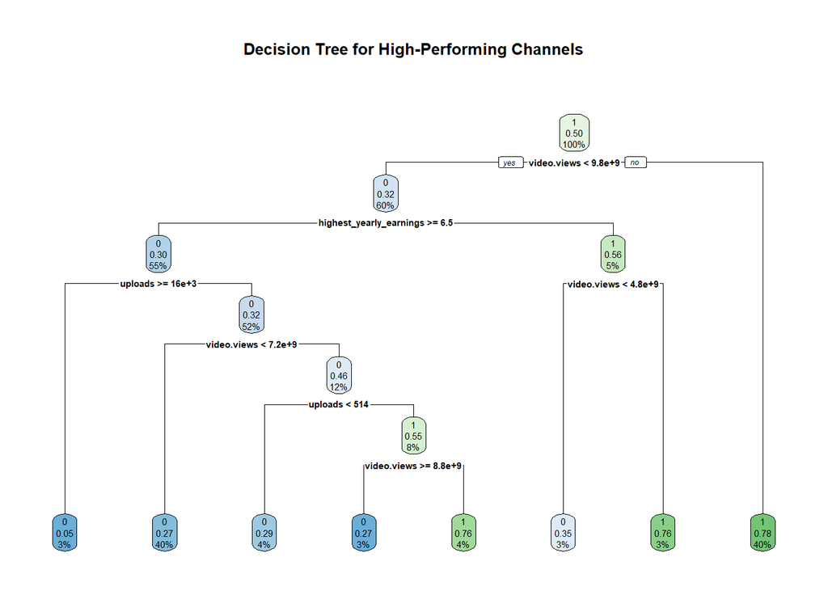

```r
# Visualize the Decision Tree
rpart.plot(decision_tree, main = "Decision Tree for High-Performing Channels")
```

```r
# Predict on test data
predictions <- predict(decision_tree, test_data, type = "class")

# Calculate confusion matrix and accuracy
confusion_matrix <- table(Predicted = predictions, Actual = test_data$is_high_performing)
accuracy <- sum(diag(confusion_matrix)) / sum(confusion_matrix)

# Print performance metrics
print(confusion_matrix)
```

```
##          Actual
## Predicted   0   1
##         0 106  40
##         1  42  94
```

```r
print(paste("Accuracy:", round(accuracy, 4)))
```

```
## [1] "Accuracy: 0.7092"
```